# Advanced Semantic Segmentation Architectures - Part 1

## How to create mask patches and orthomosaic images from shapefiles

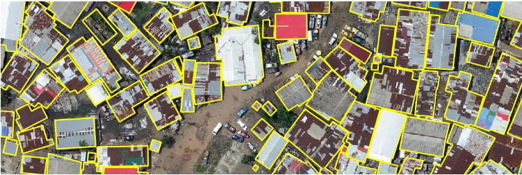

I will demonstrate how we convert target shapefiles into masks to train semantic segmentation models. The dataset used in this example is part of the Open Cities AI challenge that we will use later:

```python
!pip install rasterio
```

```
     ━━━━━━━━━━━━━━━━━━━━━━━━━━━━━━━━━━━━━━━━ 21.3/21.3 MB 44.9 MB/s eta 0:00:00
```

```python
from google.colab import drive
drive.mount('/content/drive')
```

```python
import glob
import os
import cv2
import rasterio
import geopandas as gpd
import numpy as np
import matplotlib.pyplot as plt
from tensorflow.keras.utils import to_categorical
from sklearn.model_selection import train_test_split
from sklearn.metrics import accuracy_score
from rasterio.merge import merge
from rasterio.plot import show
```

```python
path = '/content/drive/MyDrive/Datasets/OpenCitiesAI/mon/493701/493701.tif'
```

Let's open the file, read the raw data as numpy arrays and perform the band axis transposition:

```python
src = rasterio.open(path)
```

```python
img = src.read()
```

```python
img.shape
```

```
(4, 21783, 22333)
```

```python
img = img.transpose([1,2,0])
```

After opening the image stored in Drive, let's check the CRS:

```python
src.crs
```

```
CRS.from_epsg(32629)
```

Using matplotlib, let's see the image:

```
(-0.5, 22332.5, 21782.5, -0.5)
```

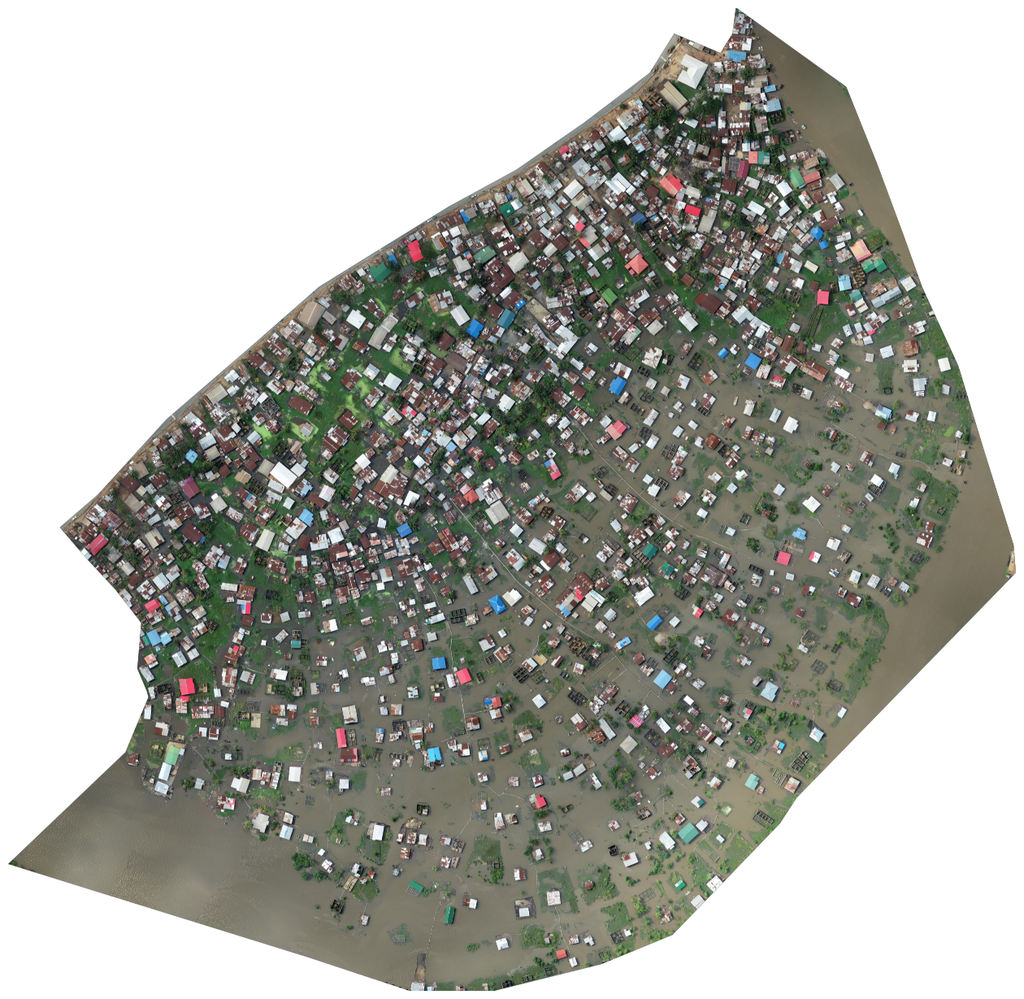

```python
plt.figure(figsize=[16,16])
plt.imshow(img)
plt.axis('off')
```

Now let's work with the labels. First we import them using Geopandas and then we set the same CRS as the Image:

```python
path_labels = '/content/drive/MyDrive/Datasets/OpenCitiesAI/mon/493701-labels/493701.geojson'
```

```python
label = gpd.read_file(path_labels)
```

```python
label = label.to_crs(32629)
```

We will also plot:

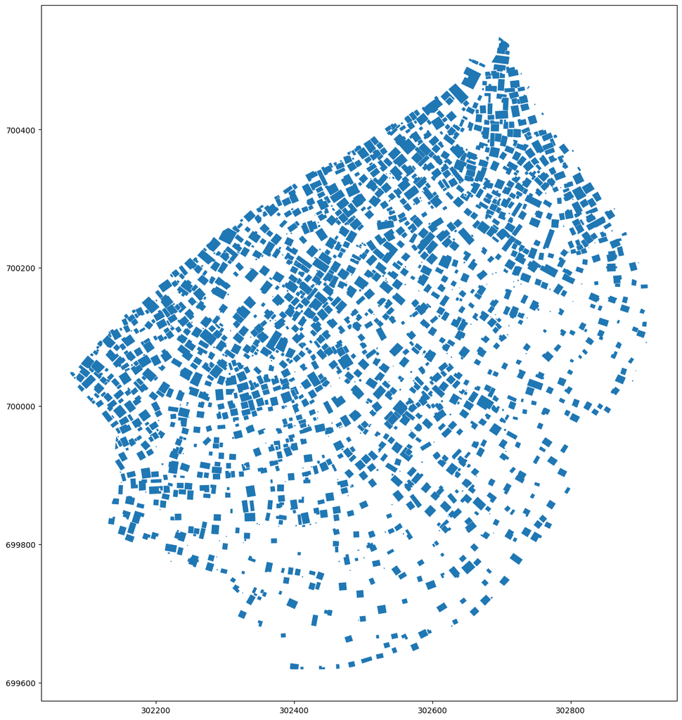

```python
label.plot(figsize=(16,16))
```

Let's use the rasterize function to convert the target vectors into an image with 0's and 1's. The number 1 represents the polygons and the 0 represents the background.

```python
from rasterio.features import rasterize
```

```python
shape_target = src.shape
out_arr = np.zeros(shape_target)
out_target = src.meta.copy()
mask_rasterized = rasterize( [(x.geometry, 1) for i, x in label.iterrows()],
                                transform=src.transform,
                                fill=0,
                                out = out_arr,
                                dtype=rasterio.uint8)
del out_arr
out_target.update({"driver": "GTiff",
                              "nodata":0,
                               "dtype":rasterio.uint8,
                               "compress":'lzw',
                               "count":1})
path_exp_target = '/content/mask_target.tif'
with rasterio.open(path_exp_target, 'w', **out_target) as msk:
    msk.write(mask_rasterized, indexes=1)
```

The resulting file was saved in /content with the name mask_target.tiff

So, let's open it up and plot it:

```python
tgt = rasterio.open(path_exp_target)
```

```python
tgt_arr = tgt.read(1)
```

```
(-0.5, 22332.5, 21782.5, -0.5)
```

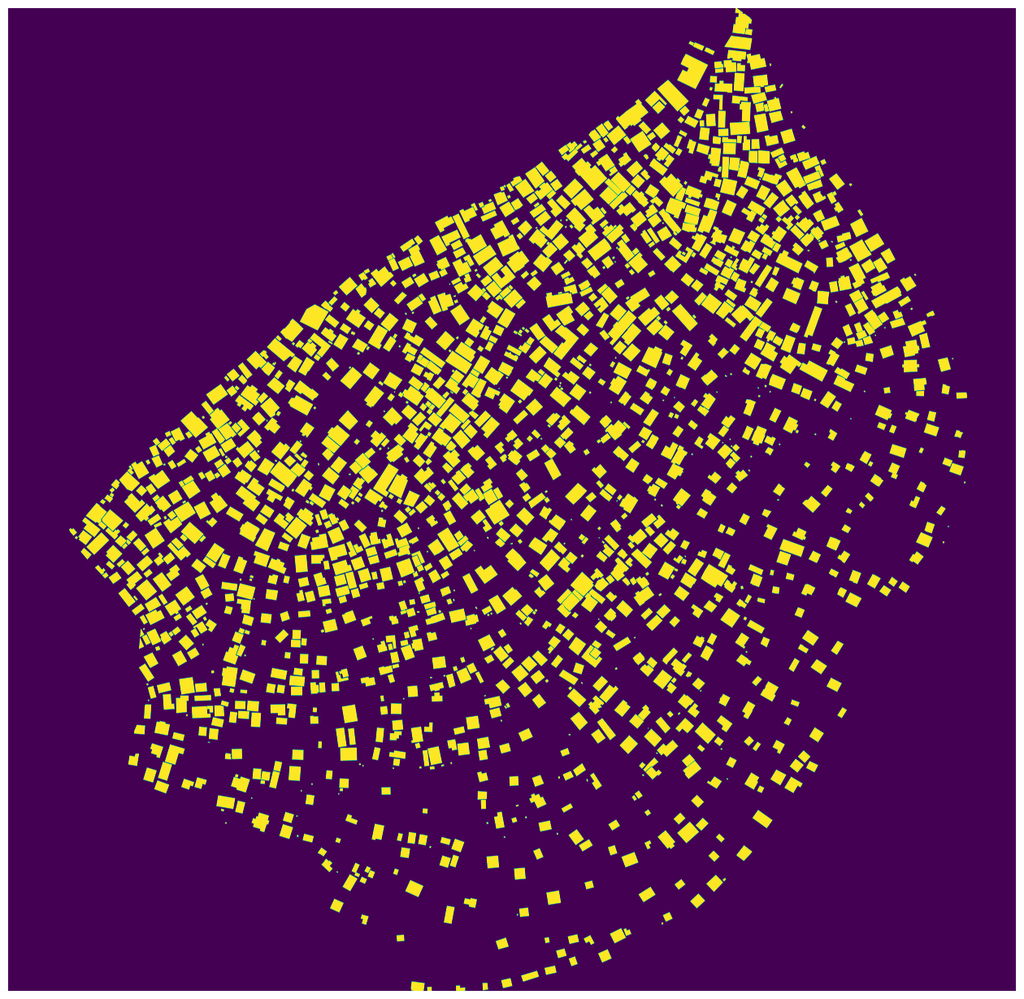

```python
plt.figure(figsize=[16,16])
plt.imshow(tgt_arr)
plt.axis('off')
```

We will create a folder in the content to store the image patches and masks:

```python
from os import mkdir
```

```python
mkdir('data')
```

And finally we will go through the image and the mask, dividing them into patches of 512x512 pixels.

```python
from rasterio.windows import Window
```

```python
qtd = 0
out_meta = src.meta.copy()
out_meta_tgt = tgt.meta.copy()
for n in range((src.meta['width']//512)):
  for m in range((src.meta['height']//512)):
    x = (n*512)
    y = (m*512)
    window = Window(x,y,512,512)
    win_transform = src.window_transform(window)
    arr_win = src.read(window=window)
    arr_win = arr_win[0:3]
    tgt_transform = tgt.window_transform(window)
    tgt_win = tgt.read(window=window)
    if (arr_win.max() != 0):
      qtd = qtd + 1
      path_exp = '/content/data/img_' + str(qtd) + '.tif'
      out_meta.update({"driver": "GTiff","height": 512,"width": 512, "count":len(arr_win), "compress":'lzw', "transform":win_transform})
      with rasterio.open(path_exp, 'w', **out_meta) as dst:
          for i, layer in enumerate(arr_win, start=1):
              dst.write_band(i, layer.reshape(-1, layer.shape[-1]))
      path_exp_mask = '/content/data/msk_' + str(qtd) + '.tif'
      out_meta_tgt.update({"driver": "GTiff","height": 512,"width": 512, "compress":'lzw', "transform":tgt_transform})
      with rasterio.open(path_exp_mask, 'w', **out_meta_tgt) as msk:
          msk.write(tgt_win.reshape(-1, tgt_win.shape[-1]), indexes=1)
      print('Create img and mask: ' + str(qtd))
    del tgt_win
    del arr_win
```

```
Create img and mask: 1
Create img and mask: 2
Create img and mask: 3
Create img and mask: 4
Create img and mask: 5
Create img and mask: 6
Create img and mask: 7
Create img and mask: 8
Create img and mask: 9
Create img and mask: 10
Create img and mask: 11
Create img and mask: 12
Create img and mask: 13
Create img and mask: 14
Create img and mask: 15
Create img and mask: 16
Create img and mask: 17
Create img and mask: 18
Create img and mask: 19
Create img and mask: 20
Create img and mask: 21
Create img and mask: 22
Create img and mask: 23
Create img and mask: 24
Create img and mask: 25
Create img and mask: 26
Create img and mask: 27
Create img and mask: 28
Create img and mask: 29
Create img and mask: 30
Create img and mask: 31
Create img and mask: 32
Create img and mask: 33
Create img and mask: 34
Create img and mask: 35
Create img and mask: 36
Create img and mask: 37
Create img and mask: 38
Create img and mask: 39
Create img and mask: 40
```

[output cut: 1143 more lines]

```
Create img and mask: 1184
Create img and mask: 1185
Create img and mask: 1186
Create img and mask: 1187
Create img and mask: 1188
Create img and mask: 1189
Create img and mask: 1190
Create img and mask: 1191
Create img and mask: 1192
Create img and mask: 1193
Create img and mask: 1194
Create img and mask: 1195
Create img and mask: 1196
Create img and mask: 1197
Create img and mask: 1198
```

Finally we can import the created patches and plot them with matplotlib:

```python
X = []
images_files = [f for f in os.listdir('/content/data/') if f.startswith('img')]
images_files.sort()
for files in images_files:
  import_raster = os.path.join('/content/data/',files)
  with rasterio.open(import_raster) as src:
    im = src.read()
    im = im.transpose([1,2,0])
    im = cv2.resize(im, (256,256))
  X.append(im)
X = np.array(X)
print(X.shape)
```

```
(1198, 256, 256, 3)
```

```python
Y = []
images_files = [f for f in os.listdir('/content/data/') if f.startswith('msk')]
images_files.sort()
for files in images_files:
  import_raster = os.path.join('/content/data/',files)
  with rasterio.open(import_raster) as src:
    im = src.read()
    im = im.transpose([1,2,0])
    im = cv2.resize(im, (256,256))
  Y.append(im)
Y = np.array(Y)
print(Y.shape)
```

```
(1198, 256, 256)
```

```
(-0.5, 255.5, 255.5, -0.5)
```

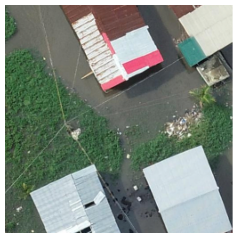

```python
plt.figure(figsize=[6,6])
plt.imshow(X[80,:,:,0:3])
plt.axis('off')
```

```
(-0.5, 255.5, 255.5, -0.5)
```

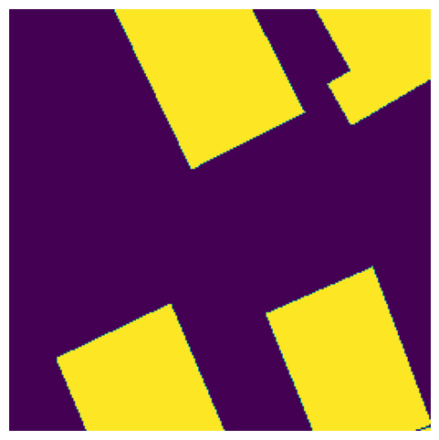

```python
plt.figure(figsize=[6,6])
plt.imshow(np.round(Y[80,:,:]))
plt.axis('off')
```

## Building Segmentation with the Open Cities AI Challenge Dataset

"In this challenge, you will be segmenting houses and buildings from aerial imagery. The data consists of drone images from 10 different cities and regions across Africa. Your goal is to classify the presence or absence of a building on a pixel-by-pixel basis."

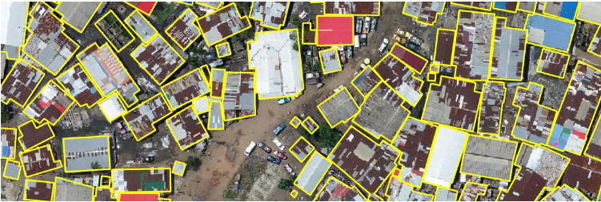

In this example, we will use the data prepared earlier to create a segmentation model for houses and buildings.

Let's plot again an example of an image and its respective mask:

```
(-0.5, 255.5, 255.5, -0.5)
```

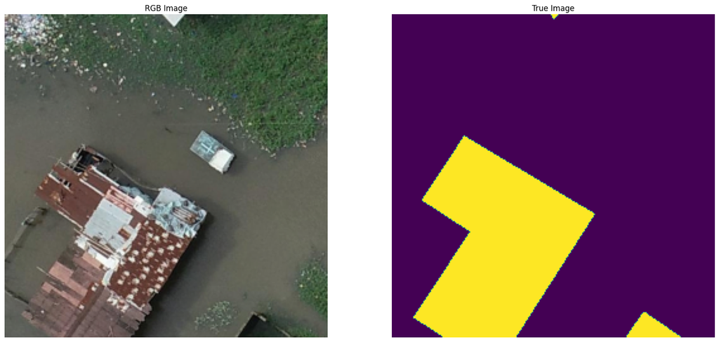

```python
i = 1000
plt.figure(figsize=[20,20])
plt.subplot(121)
plt.imshow(X[i,:,:,:])
plt.title('RGB Image')
plt.axis('off')
plt.subplot(122)
plt.imshow(Y[i,:,:])
plt.title('True Image')
plt.axis('off')
```

Now let's prepare the data to feed the neural network, dividing it into training and testing data, rescaling the values and also importing some functions from Keras:

```python
x_train, x_test, y_train, y_test = train_test_split(X, Y, test_size=0.3, random_state=10)
```

```python
x_train = x_train/255
x_test = x_test/255
```

```python
y_train = y_train.astype('float')
y_test = y_test.astype('float')
```

```python
from keras.models import Model
from keras.regularizers import l2
from keras.layers import *
from keras.models import *
import keras.backend as K
import tensorflow as tf
#from tensorflow.keras.optimizers import Adam
#from tensorflow.keras.optimizers.legacy import Adam
from keras.optimizers import Adam
from keras.losses import binary_crossentropy
from tensorflow.keras.losses import Dice
```

Let's apply data augmentation to generate more samples.

```python
img_datagen = ImageDataGenerator(
    rotation_range=90,
    vertical_flip = True,
    horizontal_flip=True)

mask_datagen = ImageDataGenerator(
    rotation_range=90,
    vertical_flip = True,
    horizontal_flip=True)
```

```python
img_datagen.fit(x_train, augment=True,seed=1200)
mask_datagen.fit(y_train[:,:,:,np.newaxis], augment=True,seed=1200)
```

```python
train_generator=img_datagen.flow(x_train,y_train[:,:,:,np.newaxis],batch_size=8,seed=1200)
```

```python
steps_per_epoch = len(x_train)//8
validation_steps = len(x_test)//8
```

## ResUnet

RESUNET is a fully convolutional neural network designed to achieve high performance with fewer parameters. It is an improvement over the existing UNET architecture. RESUNET leverages the UNET architecture and Deep Residual Learning.

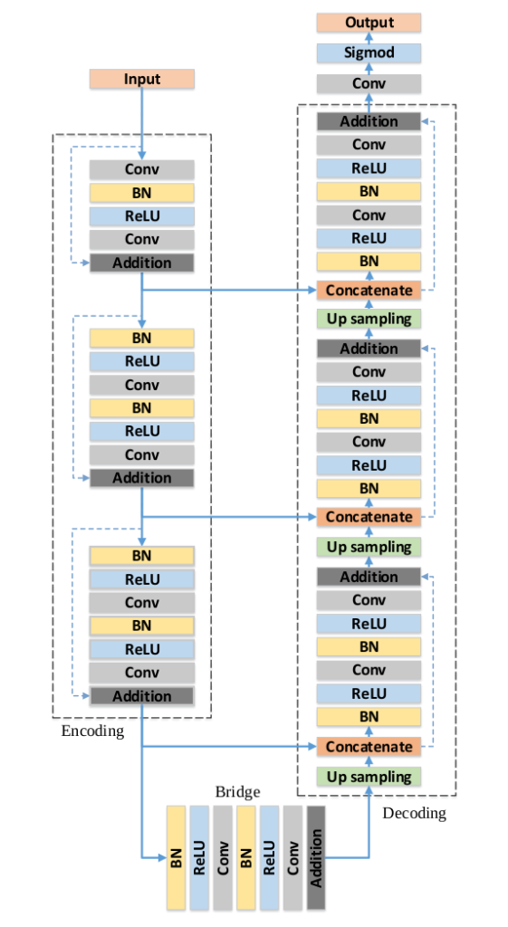

### RESUNET Advantages:

The use of residual blocks helps in building a deeper network without worrying about the problem of gradient vanishing or gradient explosion. It also helps in easy training of the network. The rich skip connections in RESUNET help in better flow of information between different layers, which helps in better flow of gradients during training (backpropagation).

### General architecture

RESUNET consists of an encoding network, a decoding network, and a bridge connecting both networks, like a U-Net. U-Net uses two 3 x 3 convolutions, each followed by a ReLU activation function. In the case of RESUNET, these layers are replaced by a pre-activated residual block.

- Encoder:

The encoder takes the input image and passes it through different encoder blocks, which helps the network learn an abstract representation. The encoder consists of three encoder blocks, which are constructed using the pre-activated residual block. The output of each encoder block acts as a skip connection to the corresponding decoder block.

To reduce the spatial dimensions (height and width) of the feature maps, the first 3×3 convolution layer uses a stride of 2 in the second and third encoder blocks. A stride value of 2 reduces the spatial dimensions by half, i.e., from 256 to 128.

- Bridge:

The bridge also consists of a pre-activated residual block with a stride value of 2.

- Decoder:

The decoder takes the feature map from the bridge and the skip connections from different encoder blocks and learns a better semantic representation, which is used to generate a segmentation mask.

The decoder consists of three decoder blocks, and after each block, the spatial dimensions of the feature map are doubled and the number of feature channels is reduced.

Let's implement ResUnet using keras:

```python
def conv_block(input_tensor, filters, strides, d_rates):
    x = Conv2D(filters[0], kernel_size=1, kernel_initializer='he_uniform', dilation_rate=d_rates[0])(input_tensor)
    x = BatchNormalization()(x)
    x = Activation('relu')(x)

    x = Conv2D(filters[1], kernel_size=3, strides=strides, kernel_initializer='he_uniform', padding='same', dilation_rate=d_rates[1])(x)
    x = BatchNormalization()(x)
    x = Activation('relu')(x)

    x = Conv2D(filters[2], kernel_size=1, kernel_initializer='he_uniform', dilation_rate=d_rates[2])(x)
    x = BatchNormalization()(x)

    shortcut = Conv2D(filters[2], kernel_size=1, kernel_initializer='he_uniform', strides=strides)(input_tensor)
    shortcut = BatchNormalization()(shortcut)

    x = add([x, shortcut])
    x = Activation('relu')(x)

    return x


def identity_block(input_tensor, filters, d_rates):
    x = Conv2D(filters[0], kernel_size=1, kernel_initializer='he_uniform', dilation_rate=d_rates[0])(input_tensor)
    x = BatchNormalization()(x)
    x = Activation('relu')(x)

    x = Conv2D(filters[1], kernel_size=3, kernel_initializer='he_uniform', padding='same', dilation_rate=d_rates[1])(x)
    x = BatchNormalization()(x)
    x = Activation('relu')(x)

    x = Conv2D(filters[2], kernel_size=1, kernel_initializer='he_uniform', dilation_rate=d_rates[2])(x)
    x = BatchNormalization()(x)

    x = add([x, input_tensor])
    x = Activation('relu')(x)

    return x

def one_side_pad(x):
    x = ZeroPadding2D((1, 1))(x)
    x = Lambda(lambda x: x[:, :-1, :-1, :])(x)
    return x
```

```python
droprate = 0.2
inputs = Input(shape=x_train.shape[1:])
conv_1 = Conv2D(32, (3, 3), strides=(1, 1), kernel_initializer='he_uniform', padding='same')(inputs)
conv_1 = BatchNormalization()(conv_1)
conv_1 = Activation("relu")(conv_1)
f1 = conv_1

conv_2 = Conv2D(64, (3, 3), strides=(2, 2), kernel_initializer='he_uniform', padding='same')(conv_1)
conv_2 = BatchNormalization()(conv_2)
conv_2 = Activation("relu")(conv_2)

conv_3 = Conv2D(64, (3, 3), strides=(1, 1), kernel_initializer='he_uniform', padding='same')(conv_2)
conv_3 = BatchNormalization()(conv_3)
conv_3 = Activation("relu")(conv_3)

f2 = conv_3


pool_1 = MaxPooling2D((2, 2), strides=(2, 2))(conv_3)

conv_block1 = conv_block(pool_1, filters=[64, 64, 128], strides=(1, 1), d_rates=[1, 1, 1])
identity_block1 = identity_block(conv_block1, filters=[64, 64, 128], d_rates=[1, 2, 1])
identity_block2 = identity_block(identity_block1, filters=[64, 64, 128], d_rates=[1, 3, 1])
f3 = identity_block2

conv_block2 = conv_block(identity_block2, filters=[128, 128, 256], strides=(2, 2), d_rates=[1, 1, 1])
identity_block3 = identity_block(conv_block2, filters=[128, 128, 256], d_rates=[1, 2, 1])
identity_block4 = identity_block(identity_block3, filters=[128, 128, 256], d_rates=[1, 3, 1])
identity_block5 = identity_block(identity_block4, filters=[128, 128, 256], d_rates=[1, 4, 1])
f4 = identity_block5


identity_block10 = conv_block(identity_block5, filters=[256, 256, 512], strides=(2, 2), d_rates=[1, 1, 1])
for i in range(5):
  identity_block10 = identity_block(identity_block10, filters=[256, 256, 512], d_rates=[1, 2, 1])

f5 = identity_block10

conv_block4 = conv_block(identity_block10, filters=[512, 512, 1024], strides=(2, 2), d_rates=[1, 1, 1])
identity_block11 = identity_block(conv_block4, filters=[512, 512, 1024], d_rates=[1, 4, 1])
identity_block12 = identity_block(identity_block11, filters=[512, 512, 1024], d_rates=[1, 4, 1])
f6 = identity_block12

o = f6

o = (BatchNormalization())(o)
o = Conv2D(1024, (3, 3), activation='relu', kernel_initializer='he_uniform', padding='same')(o)
o = Conv2D(512, (3, 3), activation='relu', kernel_initializer='he_uniform', padding='same')(o)
o = Dropout(droprate)(o)


o = Conv2DTranspose(512, (2, 2), strides=(2, 2), padding='same')(o)
o = (concatenate([o, f5]))
o = (BatchNormalization())(o)
o = Conv2D(512, (3, 3), activation='relu', kernel_initializer='he_uniform', padding='same')(o)
o = Conv2D(256, (3, 3), activation='relu', kernel_initializer='he_uniform', padding='same')(o)
o = Dropout(droprate)(o)



o = Conv2DTranspose(256, (2, 2), strides=(2, 2), padding='same')(o)
o = (concatenate([o, f4]))
o = (BatchNormalization())(o)
o = Conv2D(256, (3, 3), activation='relu', kernel_initializer='he_uniform', padding='same')(o)
o = Conv2D(128, (3, 3), activation='relu', kernel_initializer='he_uniform', padding='same')(o)
o = Dropout(droprate)(o)



o = Conv2DTranspose(128, (2, 2), strides=(2, 2), padding='same')(o)
o = (concatenate([o, f3]))
o = (BatchNormalization())(o)
o = Conv2D(128, (3, 3), activation='relu', kernel_initializer='he_uniform', padding='same')(o)
o = Conv2D(64, (3, 3), activation='relu', kernel_initializer='he_uniform', padding='same')(o)
o = Dropout(droprate)(o)



o = Conv2DTranspose(64, (2, 2), strides=(2, 2), padding='same')(o)
o = (concatenate([o, f2]))
o = (BatchNormalization())(o)
o = Conv2D(64, (3, 3), activation='relu', kernel_initializer='he_uniform', padding='same')(o)
o = Conv2D(32, (3, 3), activation='relu', kernel_initializer='he_uniform', padding='same')(o)
o = Dropout(droprate)(o)


o = Conv2DTranspose(32, (2, 2), strides=(2, 2), padding='same')(o)
o = (concatenate([o, f1]))
o = (BatchNormalization())(o)
o = Conv2D(32, (3, 3), activation='relu', kernel_initializer='he_uniform', padding='same')(o)
o = Conv2D(32, (3, 3), activation='relu', kernel_initializer='he_uniform', padding='same')(o)


o = Conv2D(1, (3, 3), padding='same', activation='sigmoid')(o)

model = Model(inputs=inputs, outputs=o)
model.compile(optimizer=Adam(learning_rate = 1e-5), loss = Dice, metrics = ['accuracy'])
model.summary()
```

```
Model: "functional"
```

[output not shown]

[output cut: 503 more lines]

[output not shown]

```
 Total params: 40,267,489 (153.61 MB)
```

```
 Trainable params: 40,227,105 (153.45 MB)
```

```
 Non-trainable params: 40,384 (157.75 KB)
```

And then we can train the model for 300 epochs:

```python
history = model.fit(train_generator,steps_per_epoch=steps_per_epoch, validation_steps=validation_steps,
                              epochs=300, validation_data=(x_test,y_test))
```

After training is complete, we will plot the accuracy and loss curves:

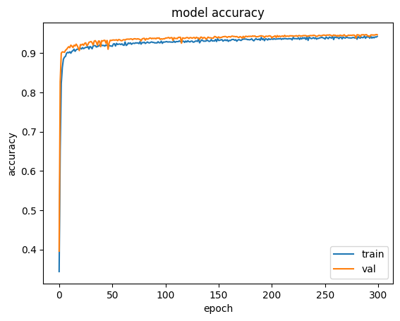

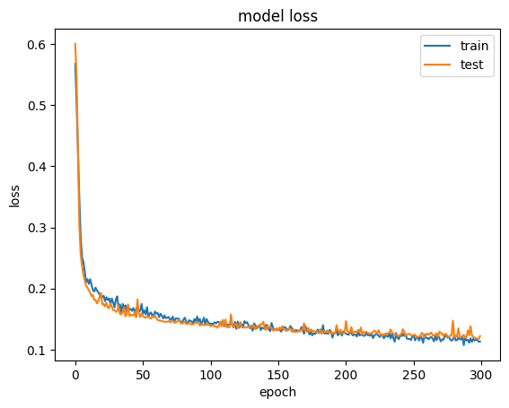

```python
plt.plot(history.history['accuracy'])
plt.plot(history.history['val_accuracy'])
plt.title('model accuracy')
plt.ylabel('accuracy')
plt.xlabel('epoch')
plt.legend(['train', 'val'], loc='lower right')
plt.show()

plt.plot(history.history['loss'])
plt.plot(history.history['val_loss'])
plt.title('model loss')
plt.ylabel('loss')
plt.xlabel('epoch')
plt.legend(['train', 'test'], loc='upper right')
plt.show()
```

Thus, we can calculate the accuracy for the test set:

```python
predict = model.predict(x_test)
```

```python
pred = np.round(predict)
```

```python
accuracy = accuracy_score(y_test.flatten(),pred.flatten())
print(accuracy)
```

```
0.9467164357503255
```

```python
y_test.shape
```

```
(360, 256, 256)
```

Finally, let's plot an example of the predicted result compared to the original mask:

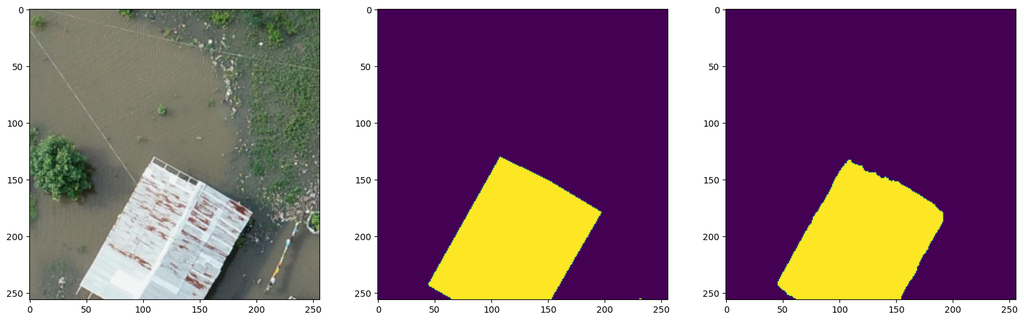

```python
i = 0
plt.figure(figsize=(20,8))
plt.subplot(1,3,1),
plt.imshow(x_test[i])
plt.subplot(1,3,2),
plt.imshow(y_test[i,:,:])
plt.subplot(1,3,3),
plt.imshow(pred[i,:,:,0])
```

## Orthomosaic Prediction

After training the model, we will apply it to the entire orthomosaic. First we divide it into 512x512 pixel windows and save it in tiff format.

```python
path_img_to_pred = '/content/drive/MyDrive/Datasets/OpenCitiesAI/mon/493701/493701.tif'
path_split = "/content/split_img"
if not os.path.isdir(path_split):
    os.mkdir(path_split)

path_exp = "/content/mask_predict"
if not os.path.isdir(path_exp):
    os.mkdir(path_exp)
```

```python
src = rasterio.open(path_img_to_pred)
out_meta = src.meta.copy()
qtd = 0
for n in range((src.meta['width']//512)):
  for m in range((src.meta['height']//512)):
    x = ((n*512))
    y = ((m*512))
    window = Window(x,y,512,512)
    win_transform = src.window_transform(window)
    arr_win = src.read(window=window)
    arr_win = arr_win[0:3]
    if (arr_win.max() != 0) and (arr_win.shape[1] == 512) and (arr_win.shape[2] == 512):
      qtd = qtd + 1
      path_exp_img = os.path.join(path_split, 'img_' + str(qtd) + '.tif')
      out_meta.update({"driver": "GTiff","height": 512,"width": 512, "count":len(arr_win), "compress":'lzw', "transform":win_transform})
      with rasterio.open(path_exp_img, 'w', **out_meta) as dst:
          for i, layer in enumerate(arr_win, start=1):
              dst.write_band(i, layer.reshape(-1, layer.shape[-1]))
      print('Create img: ' + str(qtd))
    del arr_win
```

```
Create img: 1
Create img: 2
Create img: 3
Create img: 4
Create img: 5
Create img: 6
Create img: 7
Create img: 8
Create img: 9
Create img: 10
Create img: 11
Create img: 12
Create img: 13
Create img: 14
Create img: 15
Create img: 16
Create img: 17
Create img: 18
Create img: 19
Create img: 20
Create img: 21
Create img: 22
Create img: 23
Create img: 24
Create img: 25
Create img: 26
Create img: 27
Create img: 28
Create img: 29
Create img: 30
Create img: 31
Create img: 32
Create img: 33
Create img: 34
Create img: 35
Create img: 36
Create img: 37
Create img: 38
Create img: 39
Create img: 40
```

[output cut: 1143 more lines]

```
Create img: 1184
Create img: 1185
Create img: 1186
Create img: 1187
Create img: 1188
Create img: 1189
Create img: 1190
Create img: 1191
Create img: 1192
Create img: 1193
Create img: 1194
Create img: 1195
Create img: 1196
Create img: 1197
Create img: 1198
```

Now just apply the model to each of the images:

```python
n = [f for f in os.listdir(path_split)]
```

```python
for path_img in n:
  img = []
  path_full = os.path.join(path_split,path_img)
  ds = rasterio.open(path_full, 'r')
  im = ds.read()
  im = im.transpose([1,2,0])
  im = im/255
  im = im[np.newaxis,:,:,:]
  predict = model.predict(im)
  predict = np.round(predict).astype(np.uint8)
  print(path_img.split('_')[1])
  out_meta = ds.meta.copy()
  w = ds.meta['width']
  h = ds.meta['height']
  path_exp_1 = os.path.join(path_exp,'Pred_' + path_img.split('_')[1])
  out_meta.update({"driver": "GTiff","dtype":rasterio.uint8,"compress":'lzw',"count":1,"nodata":0})
  with rasterio.open(path_exp_1, 'w', **out_meta) as dst:
      dst.write(predict[0,:,:,0], indexes=1)
```

```
649.tif
957.tif
715.tif
572.tif
655.tif
1083.tif
493.tif
366.tif
654.tif
168.tif
153.tif
1136.tif
974.tif
678.tif
443.tif
730.tif
294.tif
451.tif
722.tif
267.tif
320.tif
919.tif
1011.tif
1108.tif
855.tif
591.tif
619.tif
468.tif
401.tif
138.tif
679.tif
469.tif
492.tif
97.tif
1006.tif
474.tif
965.tif
348.tif
1158.tif
1015.tif
```

[output cut: 1143 more lines]

```
113.tif
583.tif
226.tif
363.tif
934.tif
590.tif
533.tif
1105.tif
28.tif
1061.tif
44.tif
587.tif
1100.tif
297.tif
251.tif
```

After predicting the images, we will mosaic the resulting masks into a single .tif file:

```python
out_fp = r"/content/Pred_mosaic.tif"
```

```python
images_files = [f for f in os.listdir(path_exp)]
print(images_files)
```

```
['Pred_764.tif', 'Pred_1167.tif', 'Pred_434.tif', 'Pred_700.tif', 'Pred_79.tif', 'Pred_548.tif', 'Pred_778.tif', 'Pred_499.tif', 'Pred_199.tif', 'Pred_992.tif', 'Pred_506.tif', 'Pred_108.tif', 'Pred_186.tif', 'Pred_101.tif', 'Pred_797.tif', 'Pred_1021.tif', 'Pred_848.tif', 'Pred_396.tif', 'Pred_891.…
```

```python
src_files_to_mosaic = []
for fp in images_files:
  src = rasterio.open(os.path.join(path_exp,fp))
  src_files_to_mosaic.append(src)
```

We use the rasterio merge function to join all the masks and save the result:

```python
mosaic, out_trans = merge(src_files_to_mosaic)
```

```python
out_meta.update({"driver": "GTiff",
                 "height": mosaic.shape[1],
                 "width": mosaic.shape[2],
                 "transform": out_trans,
                 "compress":'lzw'})
```

```python
with rasterio.open(out_fp, "w", **out_meta) as dest:
    dest.write(mosaic)
```

```python
predic_orto = rasterio.open('/content/Pred_mosaic.tif')
```

```python
pred_img_orto = predic_orto.read(1)
```

```
(-0.5, 22015.5, 21503.5, -0.5)
```

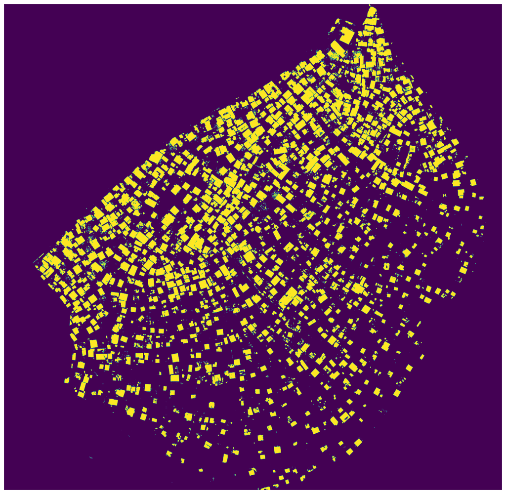

```python
plt.figure(figsize=[16,16])
plt.imshow(pred_img_orto)
plt.axis('off')
```

Let's then convert the binary image to a vector file by transforming each area defined as a built area into a polygon:

```python
from rasterio.features import shapes
from shapely.geometry import shape
```

```python
shape_gen = ((shape(s), v) for s, v in shapes(pred_img_orto, mask=pred_img_orto, transform=predic_orto.transform))
```

```python
Poly_gdf = gpd.GeoDataFrame(dict(zip(["geometry", "class"], zip(*shape_gen))), crs=predic_orto.crs)
```

```python
Poly_gdf
```

|  | geometry | class |
| --- | --- | --- |
| 0 | POLYGON ((302697.176 700533.202, 302697.386 70... | 1.0 |
| 1 | POLYGON ((302706.290 700526.692, 302706.290 70... | 1.0 |
| 2 | POLYGON ((302711.876 700520.938, 302711.876 70... | 1.0 |
| 3 | POLYGON ((302709.776 700518.796, 302709.776 70... | 1.0 |
| 4 | POLYGON ((302709.482 700517.284, 302709.482 70... | 1.0 |
| ... | ... | ... |
| 13569 | POLYGON ((302490.704 699631.546, 302490.830 69... | 1.0 |
| 13570 | POLYGON ((302501.876 699631.378, 302501.876 69... | 1.0 |
| 13571 | POLYGON ((302491.922 699634.990, 302492.006 69... | 1.0 |
| 13572 | POLYGON ((302511.158 699637.258, 302511.200 69... | 1.0 |
| 13573 | POLYGON ((302513.678 699630.958, 302513.678 69... | 1.0 |

13574 rows × 2 columns

We can filter some polygons with an area smaller than 1 square meter to remove noise.

```python
Poly_gdf_filtred = Poly_gdf[Poly_gdf.area > 1].copy()
```

Finally, we plot the result and save it in a json:

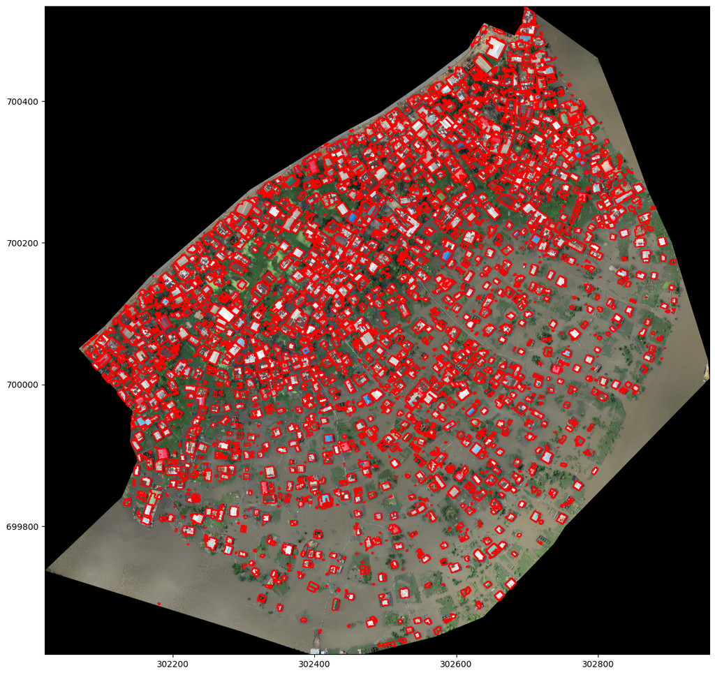

```python
fig, ax = plt.subplots(figsize=(14, 14))
with rasterio.open(path_img_to_pred) as src:
    gdf = Poly_gdf_filtred.to_crs(src.crs.to_dict()['init'])
    show(src,ax=ax)
gdf.boundary.plot(ax=ax, edgecolor='red')
```

```python
Poly_gdf_filtred.to_file('Constructions.json')
```

## Attention U-Net

To improve segmentation performance, Khened et al. and Roth et al. relied on additional object localization prior models to separate the localization and subsequent segmentation steps. This can be achieved by integrating attention gates on top of the U-Net architecture, without training additional models. As a result, attention gates incorporated into U-Net can improve the model’s sensitivity and accuracy to foreground pixels without requiring significant computational overhead. Attention gates can progressively suppress feature responses in irrelevant background regions.

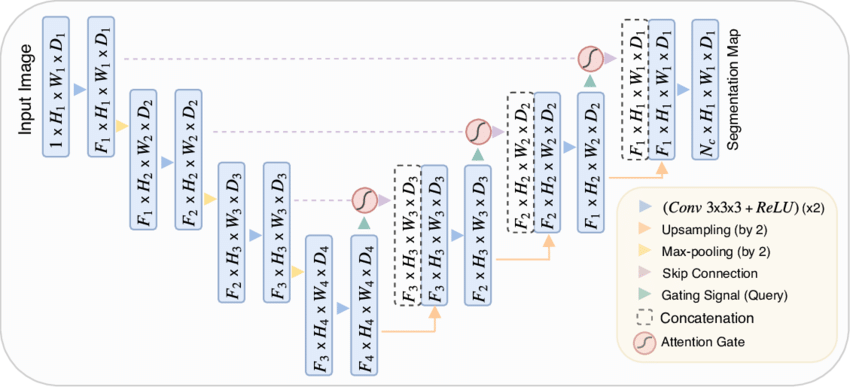

Attention gates are implemented before the concatenation operation to merge only relevant activations. Gradients originating from background regions are weighted down during the backward pass. This allows model parameters in earlier layers to be updated based on the spatial regions relevant to a given task.

To further improve the attention mechanism, Oktay et al. proposed a grid-based attention mechanism. When implementing grid-based gating, the gating signal is not a single global vector for all pixels in the image, but a grid signal conditioned on the spatial information of the image. The gating signal for each skip connection aggregates image features from multiple image scales. When using grid-based gating, this allows the attention coefficients to be more specific to local regions by increasing the grid resolution of the query signal. This achieves better performance compared to gating based on a global feature vector.

### Attention Module:

“Need to pay attention” by Jetley et al. introduced the end-to-end trainable attention module. Attention gates are commonly used in natural image analysis and natural language processing.

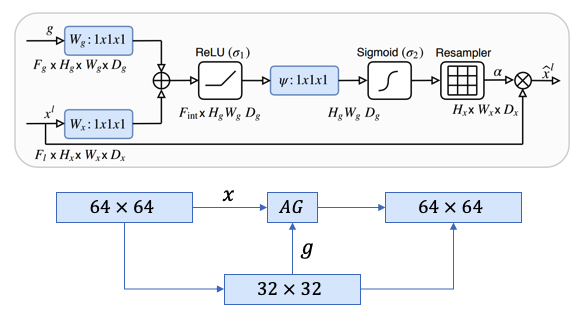

Attention is used to perform class-specific clustering, which results in more accurate and robust image classification performance. These attention maps can zoom in on relevant regions, thus demonstrating superior generalization across multiple benchmark datasets.

Let's implement Attention U-Net:

```python
from keras.layers import LeakyReLU
from keras.layers import multiply
from keras import backend as K

def expend_as(tensor, rep):
		my_repeat = Lambda(lambda x, repnum: K.repeat_elements(x, repnum, axis=3), arguments={'repnum': rep})(tensor)
		return my_repeat


def UnetGatingSignal(input, is_batchnorm=False):
		shape = K.int_shape(input)
		x = Conv2D(shape[3] * 2, (1, 1), strides=(1, 1), padding="same")(input)
		if is_batchnorm:
			x = BatchNormalization()(x)
		x = Activation('relu')(x)
		return x

def AttnGatingBlock(x, g, inter_shape):
		shape_x = K.int_shape(x)  # 32
		shape_g = K.int_shape(g)  # 16

		theta_x = Conv2D(inter_shape, (2, 2), strides=(2, 2), padding='same')(x)  # 16
		shape_theta_x = K.int_shape(theta_x)

		phi_g = Conv2D(inter_shape, (1, 1), padding='same')(g)
		upsample_g = Conv2DTranspose(inter_shape, (3, 3),strides=(shape_theta_x[1] // shape_g[1], shape_theta_x[2] // shape_g[2]),padding='same')(phi_g)  # 16

		concat_xg = add([upsample_g, theta_x])
		act_xg = Activation('relu')(concat_xg)
		psi = Conv2D(1, (1, 1), padding='same')(act_xg)
		sigmoid_xg = Activation('sigmoid')(psi)
		shape_sigmoid = K.int_shape(sigmoid_xg)
		upsample_psi = UpSampling2D(size=(shape_x[1] // shape_sigmoid[1], shape_x[2] // shape_sigmoid[2]))(sigmoid_xg)  # 32

		upsample_psi = expend_as(upsample_psi, shape_x[3])

		y = multiply([upsample_psi, x])

		result = Conv2D(shape_x[3], (1, 1), padding='same')(y)
		result_bn = BatchNormalization()(result)
		return result_bn
```

```python
inputs = Input(shape=x_train.shape[1:])
conv = Conv2D(32, (3, 3), kernel_initializer='he_uniform', padding='same')(inputs)
conv = LeakyReLU(alpha=0.3)(conv)

conv1 = Conv2D(32, (3, 3), kernel_initializer='he_uniform', padding='same')(conv)
conv1 = BatchNormalization()(conv1)
conv1 = Activation('relu')(conv1)
conv1 = Conv2D(32, (3, 3), kernel_initializer='he_uniform', padding='same')(conv1)
conv1 = BatchNormalization()(conv1)
conv1 = Activation('relu')(conv1)
pool1 = MaxPooling2D(pool_size=(2, 2))(conv1)

conv2 = Conv2D(64, (3, 3), kernel_initializer='he_uniform', padding='same')(pool1)
conv2 = BatchNormalization()(conv2)
conv2 = Activation('relu')(conv2)
conv2 = Conv2D(64, (3, 3), kernel_initializer='he_uniform', padding='same')(conv2)
conv2 = BatchNormalization()(conv2)
conv2 = Activation('relu')(conv2)
pool2 = MaxPooling2D(pool_size=(2, 2))(conv2)

conv3 = Conv2D(128, (3, 3), kernel_initializer='he_uniform', padding='same')(pool2)
conv3 = BatchNormalization()(conv3)
conv3 = Activation('relu')(conv3)
conv3 = Conv2D(128, (3, 3), kernel_initializer='he_uniform', padding='same')(conv3)
conv3 = BatchNormalization()(conv3)
conv3 = Activation('relu')(conv3)
pool3 = MaxPooling2D(pool_size=(2, 2))(conv3)

conv4 = Conv2D(256, (3, 3), kernel_initializer='he_uniform', padding='same')(pool3)
conv4 = BatchNormalization()(conv4)
conv4 = Activation('relu')(conv4)
conv4 = Conv2D(256, (3, 3), kernel_initializer='he_uniform', padding='same')(conv4)
conv4 = BatchNormalization()(conv4)
conv4 = Activation('relu')(conv4)
pool4 = MaxPooling2D(pool_size=(2, 2))(conv4)

conv5 = Conv2D(512, (3, 3), kernel_initializer='he_uniform', padding='same')(pool4)
conv5 = BatchNormalization()(conv5)
conv5 = Activation('relu')(conv5)
conv5 = Conv2D(512, (3, 3), kernel_initializer='he_uniform', padding='same')(conv5)
conv5 = BatchNormalization()(conv5)
conv5 = Activation('relu')(conv5)
pool5 = MaxPooling2D(pool_size=(2, 2))(conv5)

conv6 = Conv2D(1024, (3, 3), kernel_initializer='he_uniform', padding='same')(pool5)
conv6 = BatchNormalization()(conv6)
conv6 = Activation('relu')(conv6)
conv6 = Conv2D(512, (3, 3), kernel_initializer='he_uniform', padding='same')(conv6)
conv6 = BatchNormalization()(conv6)
conv6 = Activation('relu')(conv6)


gating1 = UnetGatingSignal(conv6, is_batchnorm=True)
attn_1 = AttnGatingBlock(conv5, gating1, 512)
up1 = concatenate([Conv2DTranspose(512, (3, 3), strides=(2, 2), padding='same',activation="relu")(conv6), attn_1], axis=3)
conv7 = Conv2D(512, (3, 3), kernel_initializer='he_uniform', padding='same')(up1)
conv7 = BatchNormalization()(conv7)
conv7 = Activation('relu')(conv7)
conv7 = Conv2D(256, (3, 3), kernel_initializer='he_uniform', padding='same')(conv7)
conv7 = BatchNormalization()(conv7)
conv7 = Activation('relu')(conv7)

gating2 = UnetGatingSignal(conv7, is_batchnorm=True)
attn_2 = AttnGatingBlock(conv4, gating2, 256)
up2 = concatenate([Conv2DTranspose(256, (3, 3), strides=(2, 2), padding='same',activation="relu")(up1), attn_2], axis=3)
conv8 = Conv2D(256, (3, 3), kernel_initializer='he_uniform', padding='same')(up2)
conv8 = BatchNormalization()(conv8)
conv8 = Activation('relu')(conv8)
conv8 = Conv2D(128, (3, 3), kernel_initializer='he_uniform', padding='same')(conv8)
conv8 = BatchNormalization()(conv8)
conv8 = Activation('relu')(conv8)


gating3 = UnetGatingSignal(conv8, is_batchnorm=True)
attn_3 = AttnGatingBlock(conv3, gating3, 128)
up3 = concatenate([Conv2DTranspose(128, (3, 3), strides=(2, 2), padding='same',activation="relu")(up2), attn_3], axis=3)
conv9 = Conv2D(128, (3, 3), kernel_initializer='he_uniform', padding='same')(up3)
conv9 = BatchNormalization()(conv9)
conv9 = Activation('relu')(conv9)
conv9 = Conv2D(64, (3, 3), kernel_initializer='he_uniform', padding='same')(conv9)
conv9 = BatchNormalization()(conv9)
conv9 = Activation('relu')(conv9)


gating4 = UnetGatingSignal(conv9, is_batchnorm=True)
attn_4 = AttnGatingBlock(conv2, gating4, 64)
up4 = concatenate([Conv2DTranspose(64, (3, 3), strides=(2, 2), padding='same',activation="relu")(up3), attn_4], axis=3)
conv10 = Conv2D(64, (3, 3), kernel_initializer='he_uniform', padding='same')(up4)
conv10 = BatchNormalization()(conv10)
conv10 = Activation('relu')(conv10)
conv10 = Conv2D(32, (3, 3), kernel_initializer='he_uniform', padding='same')(conv10)
conv10 = BatchNormalization()(conv10)
conv10 = Activation('relu')(conv10)

gating5 = UnetGatingSignal(conv10, is_batchnorm=True)
attn_5 = AttnGatingBlock(conv1, gating5, 32)
up5 = concatenate([Conv2DTranspose(32, (3, 3), strides=(2, 2), padding='same',activation="relu")(up4), attn_5], axis=3)
conv11 = Conv2D(32, (3, 3), kernel_initializer='he_uniform', padding='same')(up5)
conv11 = BatchNormalization()(conv11)
conv11 = Activation('relu')(conv11)
conv11 = Conv2D(32, (3, 3), kernel_initializer='he_uniform', padding='same')(conv11)
conv11 = BatchNormalization()(conv11)
conv11 = Activation('relu')(conv11)

conv12 = Conv2D(1, (1, 1), activation='sigmoid')(conv11)

model = Model(inputs=inputs, outputs=conv12)
model.compile(optimizer=Adam(learning_rate = 1e-5), loss = Dice, metrics=['accuracy'])
model.summary()
```

```
Model: "model_1"
__________________________________________________________________________________________________
 Layer (type)                   Output Shape         Param #     Connected to
==================================================================================================
 input_2 (InputLayer)           [(None, 256, 256, 3  0           []
                                )]

 conv2d_68 (Conv2D)             (None, 256, 256, 32  896         ['input_2[0][0]']
                                )

 leaky_re_lu (LeakyReLU)        (None, 256, 256, 32  0           ['conv2d_68[0][0]']
                                )

 conv2d_69 (Conv2D)             (None, 256, 256, 32  9248        ['leaky_re_lu[0][0]']
                                )

 batch_normalization_61 (BatchN  (None, 256, 256, 32  128        ['conv2d_69[0][0]']
 ormalization)                  )

 activation_51 (Activation)     (None, 256, 256, 32  0           ['batch_normalization_61[0][0]']
                                )

 conv2d_70 (Conv2D)             (None, 256, 256, 32  9248        ['activation_51[0][0]']
                                )

 batch_normalization_62 (BatchN  (None, 256, 256, 32  128        ['conv2d_70[0][0]']
 ormalization)                  )

 activation_52 (Activation)     (None, 256, 256, 32  0           ['batch_normalization_62[0][0]']
                                )

 max_pooling2d_1 (MaxPooling2D)  (None, 128, 128, 32  0          ['activation_52[0][0]']
                                )

 conv2d_71 (Conv2D)             (None, 128, 128, 64  18496       ['max_pooling2d_1[0][0]']
                                )

 batch_normalization_63 (BatchN  (None, 128, 128, 64  256        ['conv2d_71[0][0]']
 ormalization)                  )

```

[output cut: 103 more lines]

```
 multiply (Multiply)            (None, 16, 16, 512)  0           ['lambda[0][0]',
                                                                  'activation_60[0][0]']

 conv2d_85 (Conv2D)             (None, 16, 16, 512)  262656      ['multiply[0][0]']

 conv2d_transpose_6 (Conv2DTran  (None, 16, 16, 512)  2359808    ['activation_62[0][0]']
 spose)

 batch_normalization_74 (BatchN  (None, 16, 16, 512)  2048       ['conv2d_85[0][0]']
 ormalization)

 concatenate_5 (Concatenate)    (None, 16, 16, 1024  0           ['conv2d_transpose_6[0][0]',
                                )                                 'batch_normalization_74[0][0]']

 conv2d_86 (Conv2D)             (None, 16, 16, 512)  4719104     ['concatenate_5[0][0]']
```

```
 batch_normalization_75 (BatchN  (None, 16, 16, 512)  2048       ['conv2d_86[0][0]']
 ormalization)

 activation_66 (Activation)     (None, 16, 16, 512)  0           ['batch_normalization_75[0][0]']

 conv2d_87 (Conv2D)             (None, 16, 16, 256)  1179904     ['activation_66[0][0]']

 batch_normalization_76 (BatchN  (None, 16, 16, 256)  1024       ['conv2d_87[0][0]']
 ormalization)

 activation_67 (Activation)     (None, 16, 16, 256)  0           ['batch_normalization_76[0][0]']

 conv2d_88 (Conv2D)             (None, 16, 16, 512)  131584      ['activation_67[0][0]']

 batch_normalization_77 (BatchN  (None, 16, 16, 512)  2048       ['conv2d_88[0][0]']
 ormalization)

 activation_68 (Activation)     (None, 16, 16, 512)  0           ['batch_normalization_77[0][0]']

 conv2d_90 (Conv2D)             (None, 16, 16, 256)  131328      ['activation_68[0][0]']

 conv2d_transpose_7 (Conv2DTran  (None, 16, 16, 256)  590080     ['conv2d_90[0][0]']
 spose)

 conv2d_89 (Conv2D)             (None, 16, 16, 256)  262400      ['activation_58[0][0]']

 add_17 (Add)                   (None, 16, 16, 256)  0           ['conv2d_transpose_7[0][0]',
                                                                  'conv2d_89[0][0]']

 activation_69 (Activation)     (None, 16, 16, 256)  0           ['add_17[0][0]']

 conv2d_91 (Conv2D)             (None, 16, 16, 1)    257         ['activation_69[0][0]']

 activation_70 (Activation)     (None, 16, 16, 1)    0           ['conv2d_91[0][0]']

 up_sampling2d_1 (UpSampling2D)  (None, 32, 32, 1)   0           ['activation_70[0][0]']

 lambda_1 (Lambda)              (None, 32, 32, 256)  0           ['up_sampling2d_1[0][0]']

 multiply_1 (Multiply)          (None, 32, 32, 256)  0           ['lambda_1[0][0]',
```

[output cut: 201 more lines]

```
                                )

 batch_normalization_92 (BatchN  (None, 256, 256, 32  128        ['conv2d_115[0][0]']
 ormalization)                  )

 activation_87 (Activation)     (None, 256, 256, 32  0           ['batch_normalization_92[0][0]']
                                )

 conv2d_116 (Conv2D)            (None, 256, 256, 1)  33          ['activation_87[0][0]']

==================================================================================================
Total params: 33,840,966
Trainable params: 33,824,966
Non-trainable params: 16,000
__________________________________________________________________________________________________
```

```python
history = model.fit_generator(train_generator,steps_per_epoch=steps_per_epoch, validation_steps=validation_steps,
                              epochs=300, validation_data=(x_test,y_test))
```

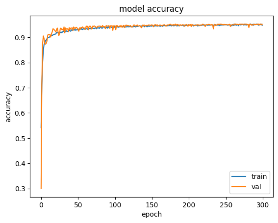

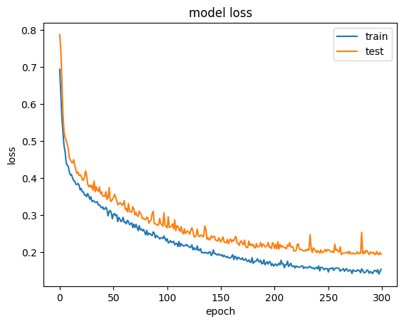

```python
plt.plot(history.history['accuracy'])
plt.plot(history.history['val_accuracy'])
plt.title('model accuracy')
plt.ylabel('accuracy')
plt.xlabel('epoch')
plt.legend(['train', 'val'], loc='lower right')
plt.show()

plt.plot(history.history['loss'])
plt.plot(history.history['val_loss'])
plt.title('model loss')
plt.ylabel('loss')
plt.xlabel('epoch')
plt.legend(['train', 'test'], loc='upper right')
plt.show()
```

Thus, we can calculate the accuracy for the test set:

```python
predict = model.predict(x_test)
```

```python
pred = np.round(predict)
```

```python
accuracy = accuracy_score(y_test.flatten(),pred.flatten())
print(accuracy)
```

```
0.9517484452989367
```

```python
y_test.shape
```

```
(360, 256, 256)
```

Finally, let's plot an example of the predicted result compared to the original mask:

[figure not shown]

```python
i = 0
plt.figure(figsize=(20,8))
plt.subplot(1,3,1),
plt.imshow(x_test[i])
plt.subplot(1,3,2),
plt.imshow(y_test[i,:,:])
plt.subplot(1,3,3),
plt.imshow(pred[i,:,:,0])
```